# Statistics as Random Variables

b06208001 龔泓愷

2018年10月26日

## Q942

1. Explaination:  
   **Condition1:** A fixed population or a repeatable situation.  
   According to the question, the probability of members utilize the service of an automobile club which is 5% is known, so the population actually exists with known proportion(p = 0.05) of those that have a trait(utilize club service).  
   **Condition2:** Random sample collected from the fixed population or a repeatable situation with independent outcomes.  
   A random sample(n = 400) is selected from the population(club).  
   **Condition3:** Large enough sample size or number of trials.  
   Both np & n(1-p) > 10.
2. n = 400, p = 0.05
3. As I mentioned in part(a), the sampling distribution of phat is **approximately normally** with `mean = p = 0.05`.  
   `p` is the population proportion, and population proportion is the same as the mean value of the sampling distribution of phat.  
   `s.d.(phat) = sqrt(p(1-p)/n) = 0.0109`.
4. `phat = 28/400 = 0.07`

```r
pnorm(0.07, mean = 0.05, sd = 0.0109, lower.tail = F)
```

```
## [1] 0.03326304
```

## Q954

1. 如圖所示

```r
p1 <- 0.51
n <- 500
theo.sd <- sqrt(p1*(1 - p1)/n);theo.sd
```

```
## [1] 0.02235621
```

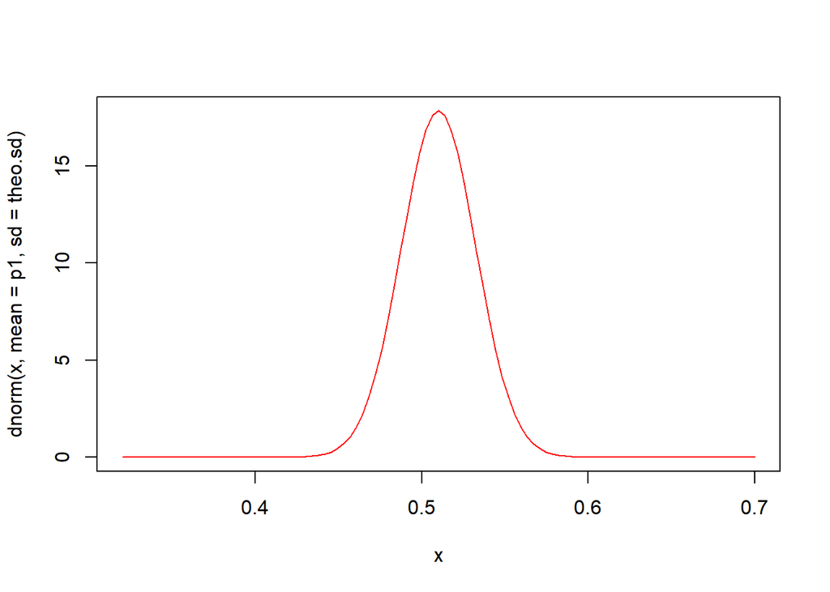

```r
curve(dnorm(x, mean = p1, sd = theo.sd), col = 'red', lwd = 1, xlim = c(0.32, 0.7))
```

2. mean of p1hat - p2hat

```r
p2 <- 0.48
mean <- p1 - p2;mean
```

```
## [1] 0.03
```

3. standard deviation of p1hat - p2hat

```r
sd <- sqrt((p1*(1-p1)/n) + (p2*(1-p2)/n));sd
```

```
## [1] 0.03160696
```

4. 如圖所示

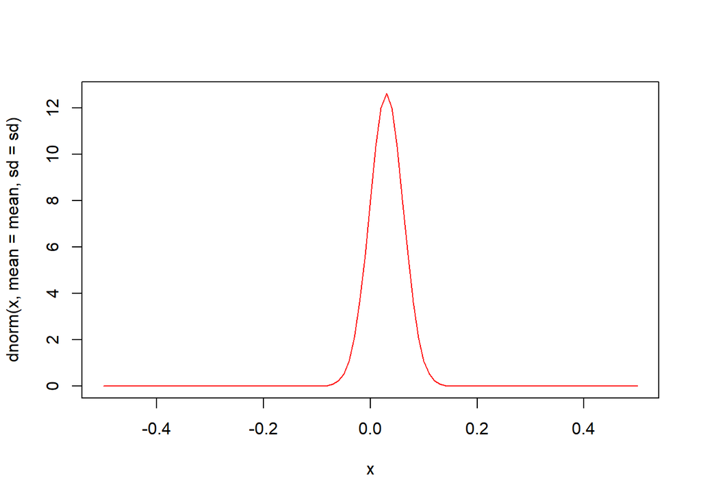

```r
curve(dnorm(x, mean = mean, sd = sd), col = 'red', lwd = 1, from = -0.5, to =0.5)
```

5. 如圖所示

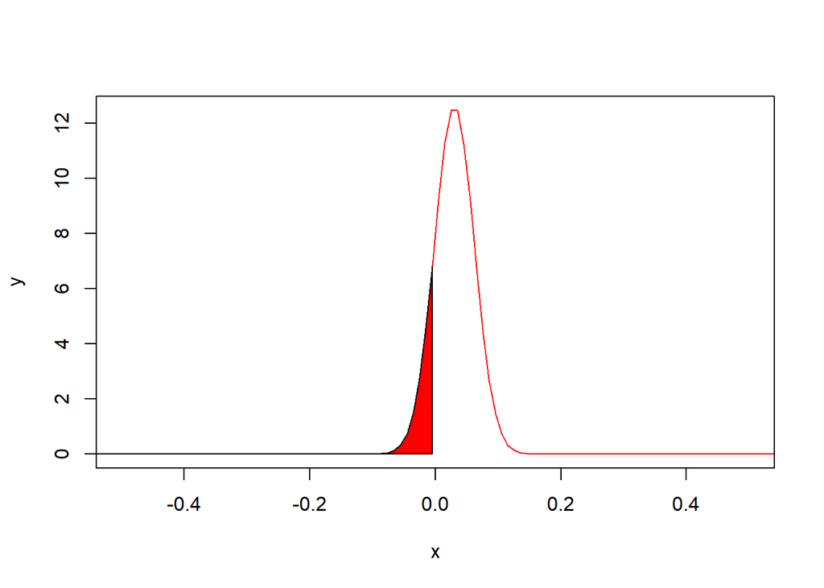

```r
x =  seq(-1, 1, length.out = 200)
y = dnorm(x, mean = mean, sd = sd)
plot(x = x, y = y, col = 'red', type = 'l', xlim = c(-0.5, 0.5))
region.x = x[x<=0]
region.y = y[x<=0]

region.x2 = c(head(region.x,1), region.x, tail(region.x,1))
region.y2 = c(0, region.y, 0)

polygon(region.x2, region.y2, col = "red")
```

6. P(X<=0)

```r
pnorm(0, mean, sd)
```

```
## [1] 0.1712701
```

## Q968

1. In the picture below, we can see that if we superimpose a normal distribution on the fact, a lot of **negative** values will show up, which is impossible in the real life.  
   As a result, we have to cut the part of the graph that has values lower than 0, and then we will have the graph which is skewed right.  
   We can now conclude that many values fall between 0 and 100, and a large spread of rare values is higher than 100 causing the right-skewed distribution.

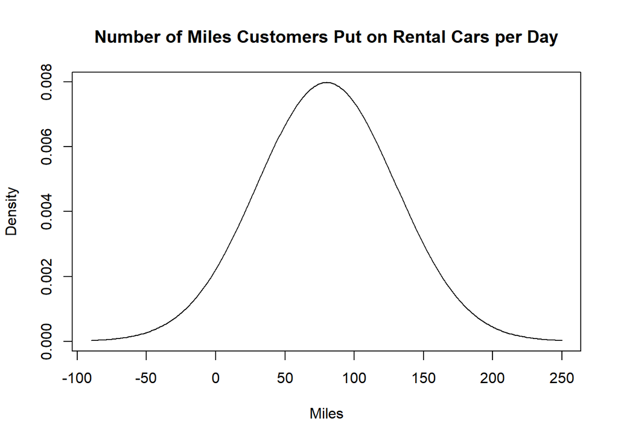

```r
Miles <- c(-90:250)
Density <- dnorm(Miles, mean = 80, sd = 50)
plot(x = Miles, y = Density, type = "l", main = 'Number of Miles Customers Put on Rental Cars per Day')
```

2. Because the sample size is larger than 30(n = 365), the sample distribution of the sample mean is approximately normal although the number of miles per day is skewed-right(Due to central limit theorm).
3. The mean number of miles multiply by 365 will be the total number of miles which is approximately normal distribution as well.
4. Yes.  
   Although the population of the measurement is not bell-shaped, the sample size is large enough(n = 365).  
   As a result, the conditions are met.

## Q974

1. Parameter of interest: The mean of the differences.  
   Notations: `mud`.
2. Statistic of interest: Sample mean of the difference.  
   Notations: `dbar`.
3. Yes.  
   If the students are randomly formed 2 groups using categorical variable(Popcorn Brand), the population will be separate into two independent parts. Thus, the parameter of interest and the statistic of sample become `mu1 - mu2` & `xbar1 - xbar2`.
4. Because the sample size(n = 50) is larger than 30, the sampling distribution of `dbar` is approximately normal.  
   `mean = mud = 10`  
   `s.d(dbar) = 5/sqrt(50) = 0.7071`
5. 如圖所示

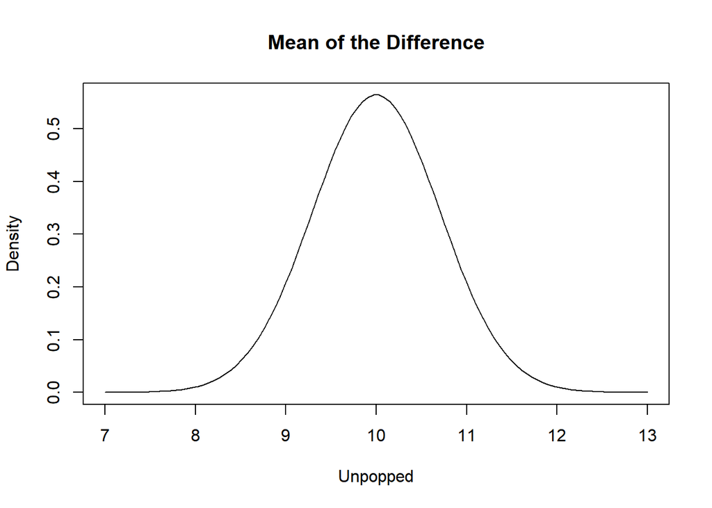

```r
Unpopped <- seq(7, 13, length.out = 100)
Density <- dnorm(Unpopped, mean = 10, sd = 0.7071)
plot(x = Unpopped, y = Density, type = "l", main = 'Mean of the Difference')
```

6. Yes.  
   On average, the store brand will have 10 fewer unpopped popcorn than name brand.  
   However, if store brand had a higher mean number of unpopped kernels than name brand which means the value of unpopped on the graph of part (e) would be negative, I would be really surprised.

## Q980

1. THe question hear assumed that there is no difference in the mean duration, as a result, the mean of the sampling distributions in sample means is 0.  
   The mean of the sampling distribution of the difference in sample means：`mean = mu1 - mu2 = 0`
2. The s.d of the sampling distribution of the difference in sample means：`s.d.(xbar1 - xbar2) = sqrt(2^2/23 + 1.5^2/25) = 0.5137`
3. 如圖所示

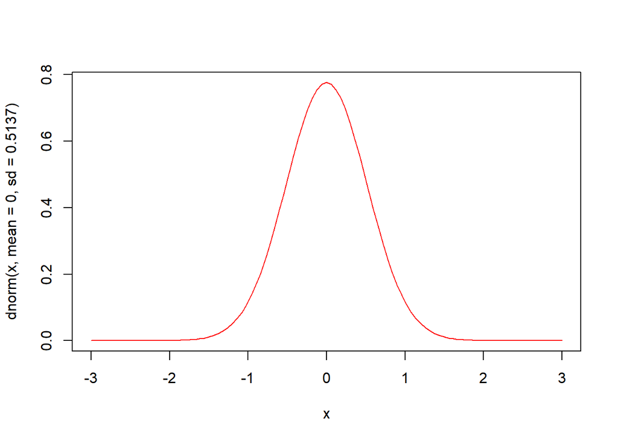

```r
curve(dnorm(x, mean = 0, sd = 0.5137), col = 'red', lwd = 1, from = -3, to =3)
```

4. No.  
   On the basis of the figure I drew in part(c),  
   if the difference in the sample mean durtion of a syptoms is 3.6 days, it’s not reasonable  
   for the value isn’t even show in the figure.
5. No.  
   From my point of view, the null hypothesis that there is no difference in the mean duration is not reasonable. A random sample from population with an unexpected value shows up, as a result, I can say that this assumption is wrong with certainty.

## Q9106

1. `(97 - 100)/15 * sqrt(36) = -1.2`
2. `(105 - 100)/15 * sqrt(36) = 2`
3. `mean = mu = 100`  
   `s.d.(xbar) = 15/sqrt(36) = 2.5`
4. 如圖所示

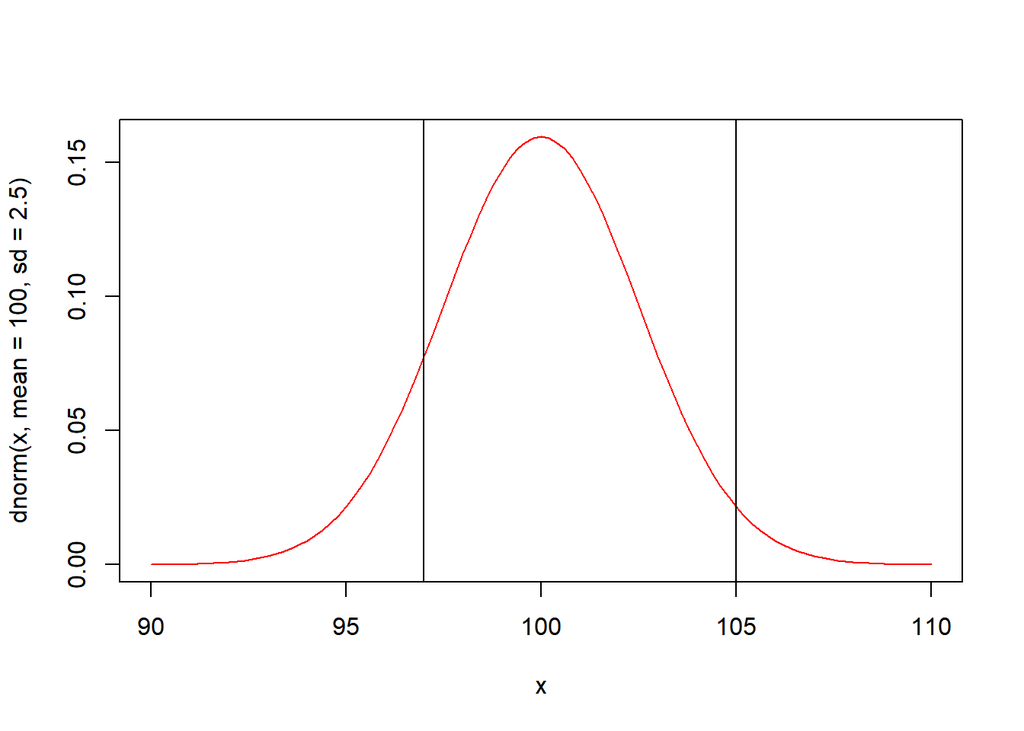

```r
curve(dnorm(x, mean = 100, sd = 2.5), col = 'red', lwd = 1, from = 90, to =110)
abline(v = 105)
abline(v = 97)
```

5. 如圖所示

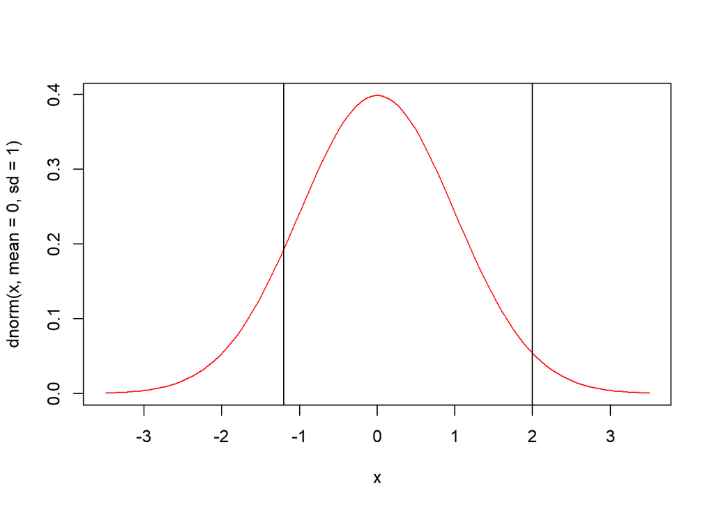

```r
curve(dnorm(x, mean = 0, sd = 1), col = 'red', lwd = 1, from = -3.5, to =3.5)#標準化後的標準差 = 1
abline(v = -1.2)
abline(v = 2)
```

6. We can see that the graph is almost identical for part(e) is just a standardized verison of part(d)

## Function Practice

### Example9.4

```r
#Each of Sampling
bino.x = function(n, p){
  samp = sample(x = c(0,1), n, replace = T, prob = c(1-p, p))
  x = sum(samp)
  phat = x/n
  return(phat)
}

#Sample Many Times
simu.phat = c()
for (i in 1:1000){#進行1000次模擬
  x = bino.x(n = 2400, p = 0.4)#每次模擬抽2400人
  simu.phat[i] = x
}

#Draw
hist(simu.phat, probability = T, breaks = 20,
     main = 'Possible Sample Proportions Favoring a Candidate',
     xlab = ('Sample Proportion'),
     col = 'gold3', border = 'white')

#Calculating simulated and theoretical values
n = 2400
p = 0.4
simu.mean = mean(simu.phat);simu.mean
```

```
## [1] 0.4006304
```

```r
simu.sd = sd(simu.phat);simu.sd
```

```
## [1] 0.009416303
```

```r
theo.mean = p;theo.mean
```

```
## [1] 0.4
```

```r
theo.sd = sqrt(p*(1-p)/n);theo.sd
```

```
## [1] 0.01
```

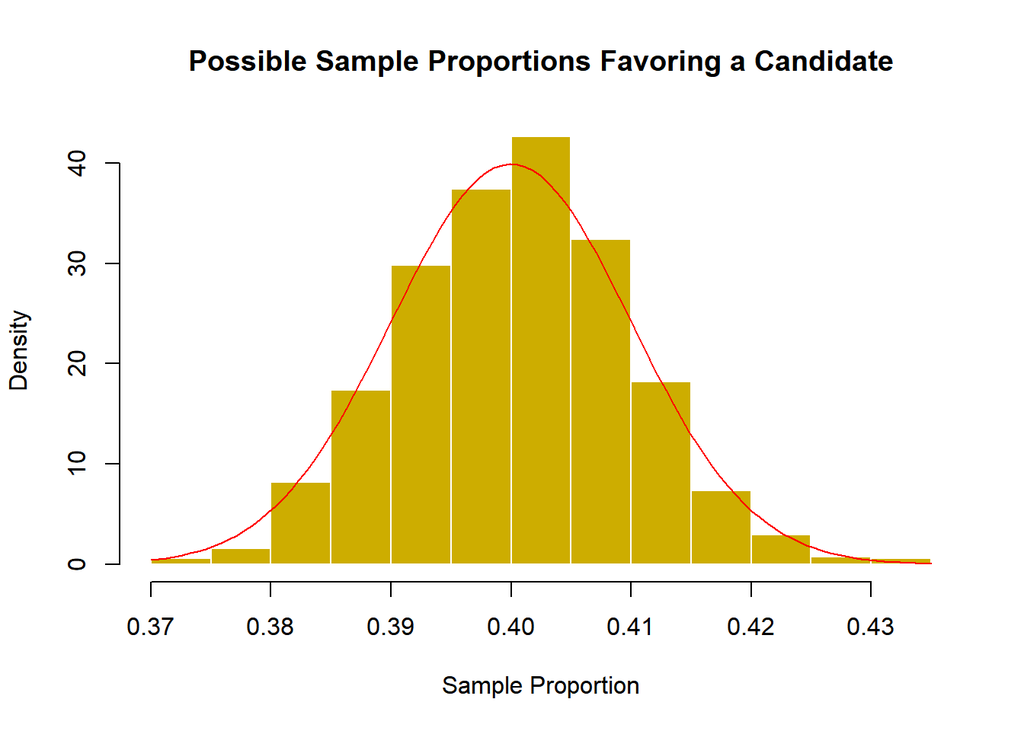

```r
#Overlapping with a curve(curve用法很特別)
curve(dnorm(x, mean = theo.mean, sd = theo.sd), add = T, col = 'red', lwd = 1)
```

```r
#Caculating Z-score
simu.z = (simu.phat - theo.mean)/theo.sd
head(simu.z)
```

```
## [1]  0.5416667  0.5833333 -0.8333333  0.7916667  1.0416667 -0.6250000
```

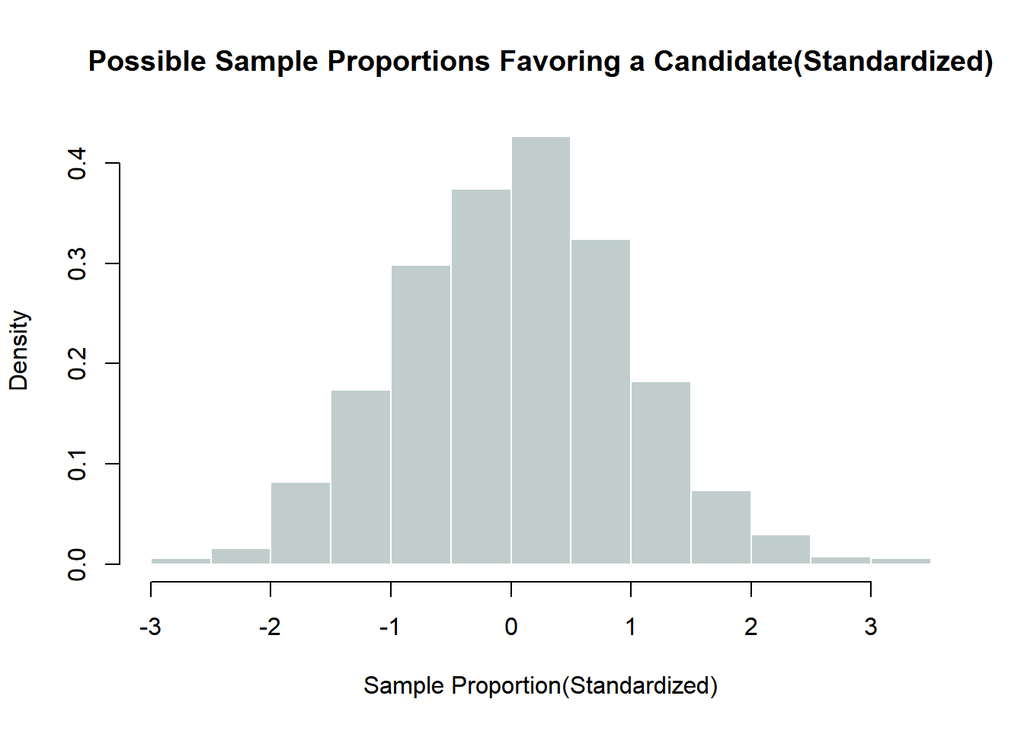

```r
hist(simu.z, probability = T, breaks = 20,
     main = 'Possible Sample Proportions Favoring a Candidate(Standardized)',
     xlab = 'Sample Proportion(Standardized)',
     col = 'azure3', border = 'white')
```

可以看出模擬值與套用公式的理論值頗為接近。

### Example9.6

```r
#Sample Many Times
simu.phat1 = c()
simu.phat2 = c()
for (i in 1:1000){#進行1000次模擬
  x = bino.x(n = 1017, p = 0.37)#每次模擬抽1017女
  simu.phat1[i] = x
}
for (i in 1:1000){#進行1000次模擬
  x = bino.x(n = 885, p = 0.27)#每次模擬抽885男
  simu.phat2[i] = x
}

simu.phat = simu.phat1 - simu.phat2

#Draw
hist(simu.phat, probability = T, breaks = 20,
     main = 'Difference in the Death Penaly of Men & Women',
     xlab = ('Difference in Sample Proportions'),
     col = 'gold3', border = 'white')

#Calculating simulated and theoretical values
n1 = 1017
n2 = 885
p1 = 0.37
p2 = 0.27
simu.mean = mean(simu.phat);simu.mean
```

```
## [1] 0.09939464
```

```r
simu.sd = sd(simu.phat);simu.sd
```

```
## [1] 0.02117153
```

```r
theo.mean = p1 - p2;theo.mean
```

```
## [1] 0.1
```

```r
theo.sd = sqrt(p1*(1-p1)/n1 + p2*(1-p2)/n2);theo.sd
```

```
## [1] 0.0212583
```

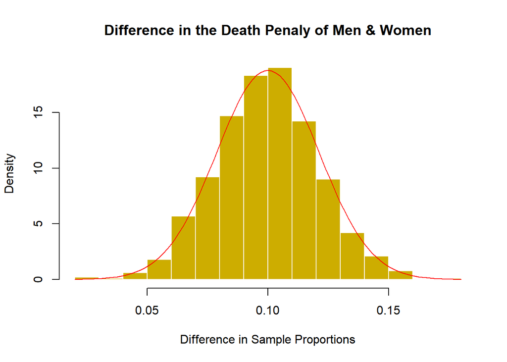

```r
#Overlapping with a curve(curve用法很特別)
curve(dnorm(x, mean = theo.mean, sd = theo.sd), add = T, col = 'red', lwd = 1)
```

```r
#Caculating Z-score
simu.z = (simu.phat - theo.mean)/theo.sd
head(simu.z)
```

```
## [1] -0.8969381  1.7988151 -0.6932631  1.7318642 -0.7228971  0.7653882
```

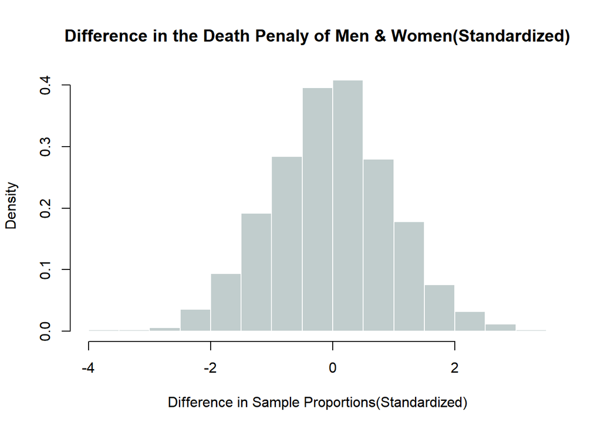

```r
hist(simu.z, probability = T, breaks = 20,
     main = 'Difference in the Death Penaly of Men & Women(Standardized)',
     xlab = 'Difference in Sample Proportions(Standardized)',
     col = 'azure3', border = 'white')
```

可以看出模擬值與套用公式的理論值頗為接近。

### Example9.8

```r
#Sample one time
#Generate random variables(samp：observations，xbar：mean of samples)
norm.x = function(mu, sigma, n){
  samp = rnorm(n, mean = mu, sd = sigma)
  xbar = mean(samp)
}

#Sample many times
simu.xbar = c()
for (i in 1:1000){#進行1000次模擬
  x = norm.x(mu = 8, sigma = 5, n = 25)
  simu.xbar[i] = x
}

#Draw
hist(simu.xbar, probability = T, breaks = 20,
     main = 'Hypothetical Mean Weight Loss',
     xlab = ('Sample Means'),
     col = 'gold3', border = 'white')

#Calculating simulated and theoretical values
mu = 8
n = 25
sigma = 5
simu.mean = mean(simu.xbar);simu.mean
```

```
## [1] 7.970812
```

```r
simu.sd = sd(simu.xbar);simu.sd
```

```
## [1] 1.001266
```

```r
theo.mean = mu;theo.mean
```

```
## [1] 8
```

```r
theo.sd = sigma/sqrt(n);theo.sd
```

```
## [1] 1
```

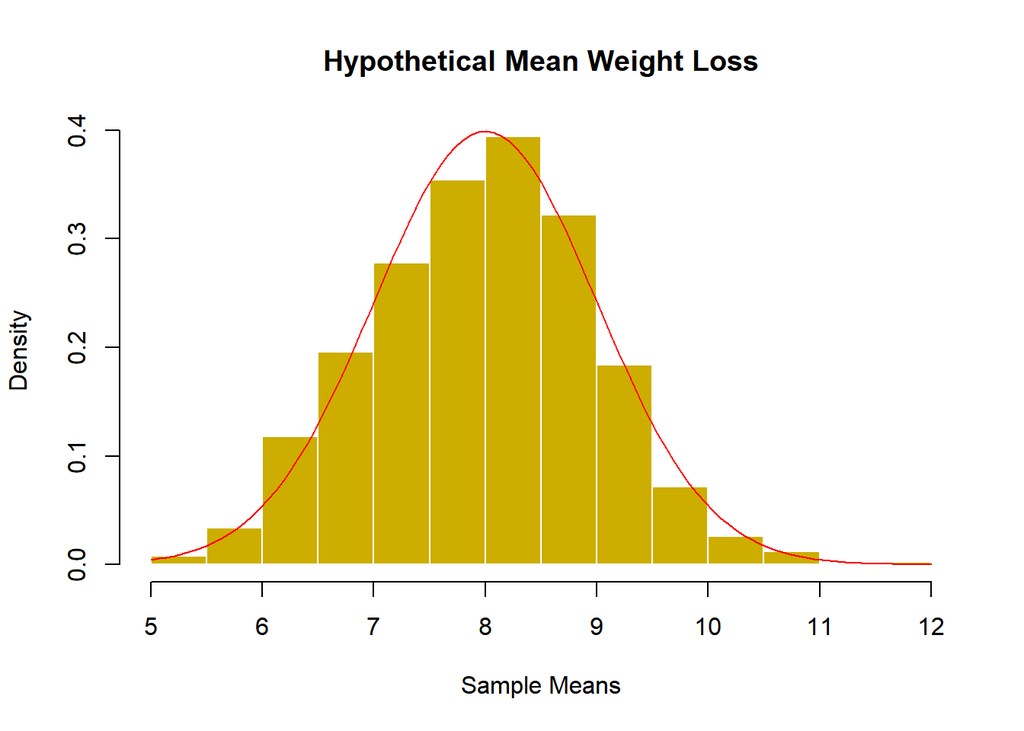

```r
#Overlapping with a curve(curve用法很特別)
curve(dnorm(x, mean = theo.mean, sd = theo.sd), add = T, col = 'red', lwd = 1)
```

```r
#Caculating Z-score
simu.z = (simu.xbar - theo.mean)/theo.sd
head(simu.z)
```

```
## [1]  0.22298017 -0.79641117  0.56836112 -0.07460457 -0.53693128  0.83890778
```

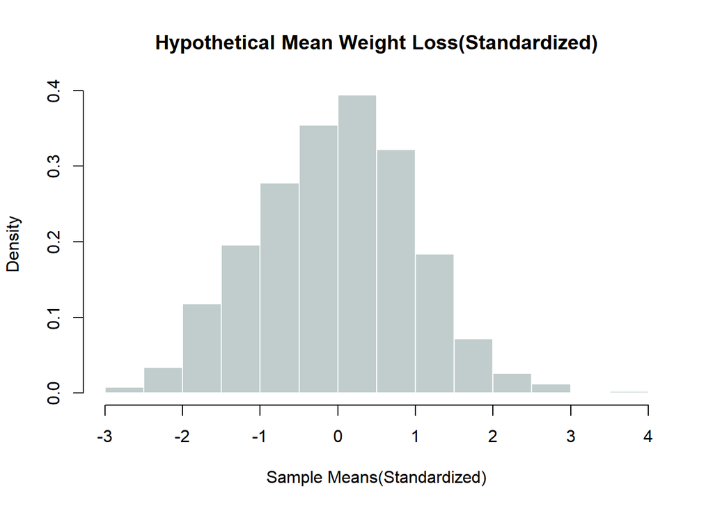

```r
hist(simu.z, probability = T, breaks = 20,
     main = 'Hypothetical Mean Weight Loss(Standardized)',
     xlab = 'Sample Means(Standardized)',
     col = 'azure3', border = 'white')
```

可以看出模擬值與套用公式的理論值頗為接近。

### Example9.9

```r
#Sample many times
simu.dbar = c()
for (i in 1:1000){#進行1000次模擬
  x = norm.x(mu = 0, sigma = 7, n = 60)
  simu.dbar[i] = x
}

#Draw
hist(simu.dbar, probability = T, breaks = 20,
     main = 'Suppose That There Is No "Freshman15"',
     xlab = ('Possible Values of dbar'),
     col = 'gold3', border = 'white')

#Calculating simulated and theoretical values
mu = 0
n = 60
sigma = 7
simu.mean = mean(simu.dbar);simu.mean
```

```
## [1] 0.004250459
```

```r
simu.sd = sd(simu.dbar);simu.sd
```

```
## [1] 0.9102061
```

```r
theo.mean = mu;theo.mean
```

```
## [1] 0
```

```r
theo.sd = sigma/sqrt(n);theo.sd
```

```
## [1] 0.9036961
```

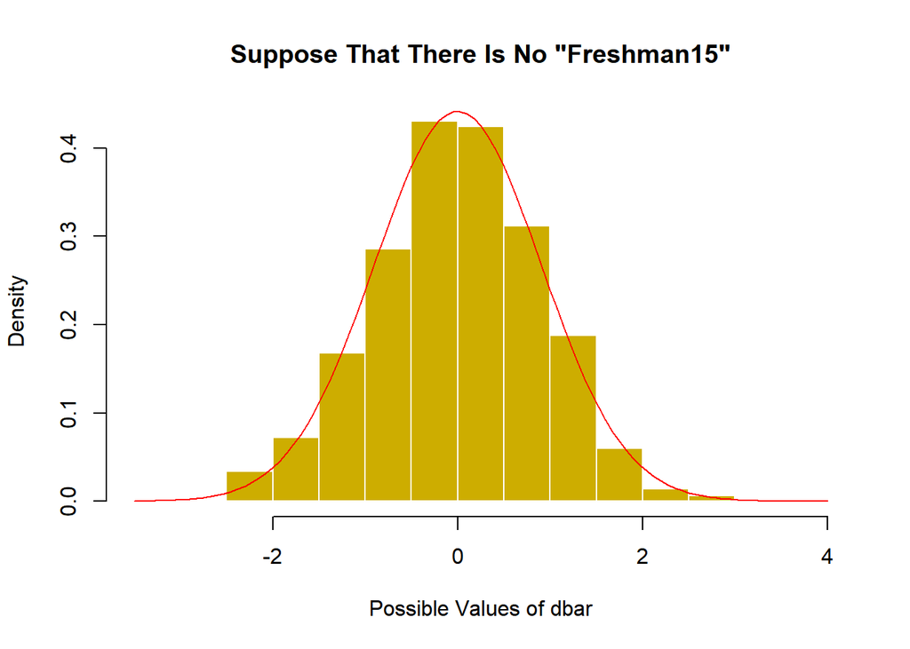

```r
#Overlapping with a curve(curve用法很特別)
curve(dnorm(x, mean = theo.mean, sd = theo.sd), add = T, col = 'red', lwd = 1)
```

```r
#Caculating Z-score
simu.z = (simu.dbar - theo.mean)/theo.sd
head(simu.z)
```

```
## [1] -1.8520525  0.8700872 -0.7973151  0.4538995 -1.5463012  0.1300632
```

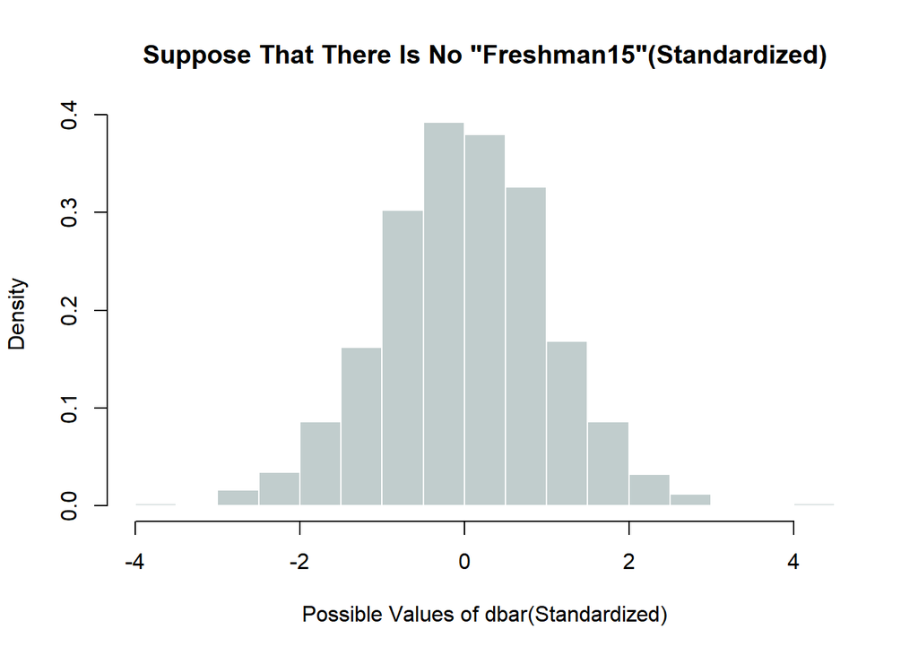

```r
hist(simu.z, probability = T, breaks = 20,
     main = 'Suppose That There Is No "Freshman15"(Standardized)',
     xlab = 'Possible Values of dbar(Standardized)',
     col = 'azure3', border = 'white')
```

題目假設mud = 0，可以看出模擬值與套用公式的理論值頗為接近。  
然而某次採樣dbar高達4.2，在3個標準差範圍之外，可以猜測mud = 0的假設可能是有誤。

### Example9.10

```r
#Sample many times
simu.xbar1 = c()
simu.xbar2 = c()
for (i in 1:1000){#進行1000次模擬
  x = norm.x(mu = 88, sigma = 15, n = 87)#每次模擬抽87男
  simu.xbar1[i] = x
}

for (i in 1:1000){#進行1000次模擬
  x = norm.x(mu = 88, sigma = 15, n = 102)#每次模擬抽102女
  simu.xbar2[i] = x
}

simu.xbar = simu.xbar1 - simu.xbar2

#Draw
hist(simu.xbar, probability = T, breaks = 20,
     main = 'Who Are the Speed Demons?',
     xlab = ('Difference in Sample Means'),
     col = 'gold3', border = 'white')

#Calculating simulated and theoretical values
mu1 = 88#題目沒有給
mu2 = 88#題目沒有給
sigma1 = 15
sigma2 = 15
n1 = 87
n2 = 102
simu.mean = mean(simu.xbar);simu.mean
```

```
## [1] -0.05952002
```

```r
simu.sd = sd(simu.xbar);simu.sd
```

```
## [1] 2.222149
```

```r
theo.mean = mu1 - mu2;theo.mean
```

```
## [1] 0
```

```r
theo.sd = sqrt(sigma1^2/n1 + sigma2^2/n2);theo.sd
```

```
## [1] 2.189084
```

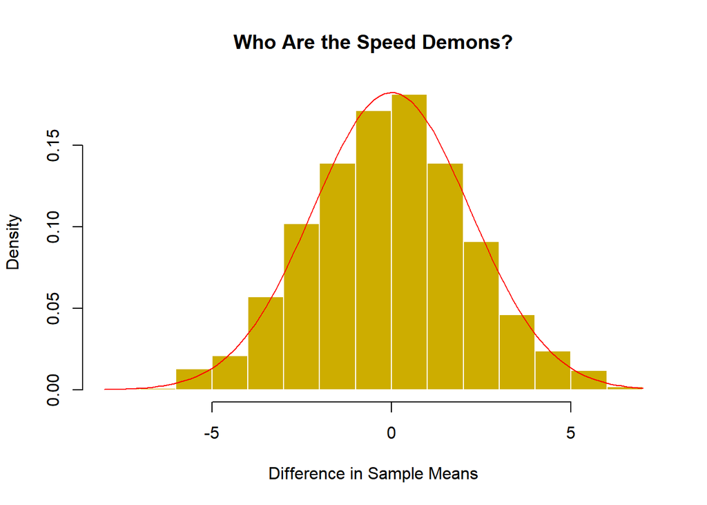

```r
#Overlapping with a curve(curve用法很特別)
curve(dnorm(x, mean = theo.mean, sd = theo.sd), add = T, col = 'red', lwd = 1)
```

```r
#Caculating Z-score
simu.z = (simu.xbar - theo.mean)/theo.sd
head(simu.z)
```

```
## [1] -1.0850224  0.3560729  1.1243614  1.1256897  0.3543213 -1.5976595
```

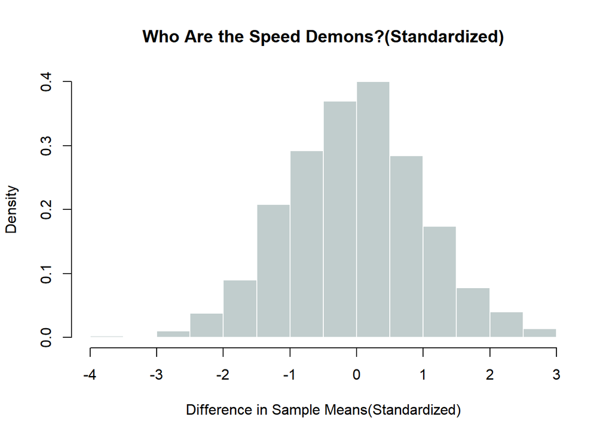

```r
hist(simu.z, probability = T, breaks = 20,
     main = 'Who Are the Speed Demons?(Standardized)',
     xlab = 'Difference in Sample Means(Standardized)',
     col = 'azure3', border = 'white')
```

題目假設mu1 - mu2 = 0，可以看出模擬值與套用公式的理論值頗為接近。  
然而某次採樣的樣本平均差異高達19，遠在3個標準差範圍之外，可以猜測mu1 - mu2 = 0假設可能有誤。